# vegetation-project

## Set Up

```python
# Import Libraries

import json                 # Reading and writing JSON
from glob import glob       # File pattern matching
import os                   # Operating system access
import pathlib              # File navigation
import holoviews as hv      # Interactable plot
import panel as pn          # Plot formatting
pn.extension()              # Plot formatting
hv.extension('bokeh')       # Interactable plot

import earthpy              # Work with geospatial data
import xarray as xr         # Multi-dimensional arrays
import hvplot.xarray        # HVPlot and xarray
import rioxarray as rxr     # Raster for xarray

import matplotlib.pyplot as plt    # Plotting
import pandas as pd         # Work with tabular data
import geopandas as gpd     # Wowk with geospatial data
import hvplot.pandas        # Plot geospatial data
```

## Download Data

> The dataset is saved as 'Gila River Vegetation.'

```python
project = earthpy.Project(
    'Gila River Vegetation', dirname='gric-vegetation-project')
project.get_data()
```

> The 2020 American Indian Tribal Subdivision National (AITSN) borders from the 2020 US census are included in the data downloaded. More information about the shapefiles can be found [here](https://catalog.data.gov/dataset/2020-cartographic-boundary-file-shp-american-indian-tribal-subdivision-aits-for-united-states-1).

```python
# Load in the boundary data
aitsn_gdf = gpd.read_file(project.project_dir / 'tl_2020_us_aitsn')

# Check that it worked
print(type(aitsn_gdf))

aitsn_gdf.head()
```

```
<class 'geopandas.geodataframe.GeoDataFrame'>
```

|  | AIANNHCE | TRSUBCE | TRSUBNS | GEOID | NAME | NAMELSAD | LSAD | CLASSFP | MTFCC | FUNCSTAT | ALAND | AWATER | INTPTLAT | INTPTLON | geometry |
| --- | --- | --- | --- | --- | --- | --- | --- | --- | --- | --- | --- | --- | --- | --- | --- |
| 0 | 2430 | 653 | 02419073 | 2430653 | Red Valley | Red Valley Chapter | T2 | D7 | G2300 | A | 922036695 | 195247 | +36.6294607 | -109.0550394 | POLYGON ((-109.2827 36.64644, -109.28181 36.65... |
| 1 | 2430 | 665 | 02419077 | 2430665 | Rock Point | Rock Point Chapter | T2 | D7 | G2300 | A | 720360268 | 88806 | +36.6598701 | -109.6166836 | POLYGON ((-109.85922 36.49859, -109.85521 36.5... |
| 2 | 2430 | 675 | 02419081 | 2430675 | Rough Rock | Rough Rock Chapter | T2 | D7 | G2300 | A | 364475668 | 216144 | +36.3976971 | -109.7695183 | POLYGON ((-109.93053 36.40672, -109.92923 36.4... |
| 3 | 2430 | 325 | 02418975 | 2430325 | Indian Wells | Indian Wells Chapter | T2 | D7 | G2300 | A | 717835323 | 133795 | +35.3248534 | -110.0855000 | POLYGON ((-110.24222 35.36327, -110.24215 35.3... |
| 4 | 2430 | 355 | 02418983 | 2430355 | Kayenta | Kayenta Chapter | T2 | D7 | G2300 | A | 1419241065 | 1982848 | +36.6884391 | -110.3045616 | POLYGON ((-110.56817 36.73489, -110.56603 36.7... |

> Through some trial and error, I found latitude and longitude boundaries to focus the plot on the Gila River Indian Community. The AIANNHCE value 1310 can then be used to create a new GDF containing just the GRIC Boundaries.

```python
# Generate plot of surrounding area with Tribal locations highlighted
aitsn_gdf.hvplot(
    geo=True, tiles='EsriImagery',
    frame_width=500,
    legend=False, fill_color=None, edge_color='white',
    hover_cols='all',
    xlim=(-112.4, -111.4),
    ylim=(32.8, 33.6)
)
```

```
WARNING:param.main: edge_color option not found for polygons plot with bokeh; similar options include: ['muted_color', 'bgcolor', 'line_color']
```

```python
# Select and merge the subdivisions we want (1310)
gric_gdf = aitsn_gdf.loc[aitsn_gdf.AIANNHCE=='1310'].dissolve()
# Plot the results with web tile images
gric_gdf.hvplot()
```

```python
# Create the boundary GDF
boundary_gdf = aitsn_gdf.loc[aitsn_gdf.AIANNHCE=='1310'].dissolve()

# Plot the results with web tile images
boundary_gdf.hvplot(
    geo=True, tiles='EsriImagery',
    fill_color='green', line_color='black',
    fill_alpha=.3,  # must be b/w 0-1
    title='Gila River Indian Community',
    frame_width=500)
```

## Set up NDVI data

> Create and combine a list of the raster files with the unique date for each raster now included as an extra dimension to the (x,y) spatial data.

```python
# Get a sorted list of NDVI tif file paths
ndvi_paths = sorted(list(project.project_dir.rglob('*NDVI*.tif')))

# Display the first and last three files paths to check the pattern
ndvi_paths[:3], ndvi_paths[-3:]
```

```
([PosixPath('/workspaces/data/gric-vegetation-project/gila-river-ndvi/MOD13Q1.061_2001137_to_2022244/MOD13Q1.061__250m_16_days_NDVI_doy2001145000000_aid0001.tif'),
  PosixPath('/workspaces/data/gric-vegetation-project/gila-river-ndvi/MOD13Q1.061_2001137_to_2022244/MOD13Q1.061__250m_16_days_NDVI_doy2001161000000_aid0001.tif'),
  PosixPath('/workspaces/data/gric-vegetation-project/gila-river-ndvi/MOD13Q1.061_2001137_to_2022244/MOD13Q1.061__250m_16_days_NDVI_doy2001177000000_aid0001.tif')],
 [PosixPath('/workspaces/data/gric-vegetation-project/gila-river-ndvi/MOD13Q1.061_2001137_to_2022244/MOD13Q1.061__250m_16_days_NDVI_doy2022209000000_aid0001.tif'),
  PosixPath('/workspaces/data/gric-vegetation-project/gila-river-ndvi/MOD13Q1.061_2001137_to_2022244/MOD13Q1.061__250m_16_days_NDVI_doy2022225000000_aid0001.tif'),
  PosixPath('/workspaces/data/gric-vegetation-project/gila-river-ndvi/MOD13Q1.061_2001137_to_2022244/MOD13Q1.061__250m_16_days_NDVI_doy2022241000000_aid0001.tif')])
```

```python
# Loop through each NDVI image to add date dimension

doy_start = -25
doy_end = -19

ndvi_das = []

for ndvi_path in ndvi_paths:
    # Get date from file name
    doy = ndvi_path.name[doy_start:doy_end]
    date = pd.to_datetime(doy, format='%Y%j')

    # Open dataset
    da = rxr.open_rasterio(ndvi_path, mask_and_scale=True).squeeze()

    # Add date dimension and clean up metadata
    da = da.assign_coords({'date': date})
    da = da.expand_dims({'date': 1})
    da.name = 'NDVI'

    # Prepare for concatenation
    ndvi_das.append(da)

len(ndvi_das)
```

```
154
```

> Combine the list of rasters into a new data xarray "sliced" by the dates.

```python
# Combine NDVI images from all dates
ndvi_da = xr.combine_by_coords(ndvi_das, coords=['date'])

ndvi_da
```

```
<xarray.Dataset> Size: 48MB
Dimensions:      (date: 154, y: 203, x: 382)
Coordinates:
    band         int64 8B 1
  * x            (x) float64 3kB -112.3 -112.3 -112.3 ... -111.5 -111.5 -111.5
  * y            (y) float64 2kB 33.39 33.39 33.38 33.38 ... 32.97 32.97 32.97
    spatial_ref  int64 8B 0
  * date         (date) datetime64[ns] 1kB 2001-01-14 2001-01-16 ... 2022-01-24
Data variables:
    NDVI         (date, y, x) float32 48MB 0.8282 0.6146 ... 0.2146 0.2085
```

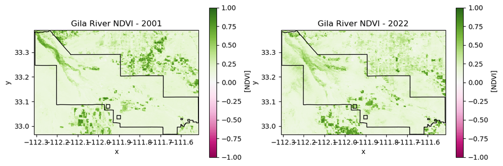

```python
# Plot first and last files side by side to visualize progress
first_ndvi = rxr.open_rasterio(ndvi_paths[0], mask_and_scale=True).squeeze()
last_ndvi = rxr.open_rasterio(ndvi_paths[-1], mask_and_scale=True).squeeze()

fig, axes = plt.subplots(1, 2, figsize = (12, 4))

first_ndvi.plot(ax=axes[0], cmap=plt.cm.PiYG, vmin=-1, vmax=1)
axes[0].set_title("Gila River NDVI - 2001")
boundary_gdf.plot(ax=axes[0], edgecolor='black', facecolor='none',
                  linewidth=1)


last_ndvi.plot(ax=axes[1], cmap=plt.cm.PiYG, vmin=-1, vmax=1)
axes[1].set_title("Gila River NDVI - 2022")
boundary_gdf.plot(ax=axes[1], edgecolor='black', facecolor='none',
                  linewidth=1)
```

> Calculate mean values for NDVI from the beginning of the dataset in 2001 to the water rights settlement in 2004 and an xarray of rasters for each year post 2004.

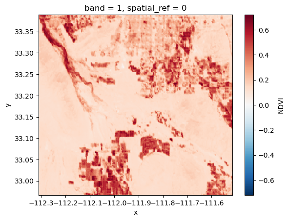

```python
# Compute the mean NDVI values before water rights were restored
ndvi_pre = (ndvi_da
             .sel(date=slice('2001', '2004'))
             .mean('date')
             .NDVI
)

ndvi_pre.plot()
```

```python
ndvi_post = ndvi_da.sel(date=slice('2005', '2022')).NDVI

ndvi_post_yearly = ndvi_post.groupby('date.year').mean('date')

print (ndvi_post_yearly)

len(ndvi_post_yearly)
```

```
<xarray.DataArray 'NDVI' (year: 18, y: 203, x: 382)> Size: 6MB
array([[[0.5380143 , 0.47134283, 0.4491    , ..., 0.17115715,
         0.17115715, 0.175     ],
        [0.53234285, 0.43379998, 0.44574285, ..., 0.14785714,
         0.14785714, 0.16301428],
        [0.50931424, 0.4504714 , 0.40725714, ..., 0.1275    ,
         0.1056857 , 0.07895714],
        ...,
        [0.18635714, 0.18635714, 0.17112856, ..., 0.17614286,
         0.17614286, 0.17889999],
        [0.17275715, 0.17275715, 0.16979997, ..., 0.21141426,
         0.21141426, 0.2217714 ],
        [0.18247142, 0.17312858, 0.18251428, ..., 0.20607142,
         0.26507142, 0.2588    ]],

       [[0.6633143 , 0.5207143 , 0.4350571 , ..., 0.14278571,
         0.14278571, 0.14188571],
        [0.6846143 , 0.5030286 , 0.35744286, ..., 0.11975714,
         0.11975714, 0.12397142],
        [0.5164143 , 0.42664286, 0.3745286 , ..., 0.13028571,
         0.09927142, 0.07134286],
...
        [0.14237143, 0.14237143, 0.13668571, ..., 0.16885713,
         0.16885713, 0.17524286],
        [0.1333857 , 0.1333857 , 0.13745713, ..., 0.21079998,
         0.21079998, 0.21817143],
        [0.15061429, 0.13785715, 0.13837144, ..., 0.16395713,
         0.21935715, 0.2031714 ]],

       [[0.6115714 , 0.45694283, 0.40044284, ..., 0.16761427,
         0.16761427, 0.16799998],
        [0.5378714 , 0.44529995, 0.35509998, ..., 0.15104285,
         0.15104285, 0.15302856],
        [0.33719996, 0.37427142, 0.4122714 , ..., 0.1349    ,
         0.11072857, 0.09608571],
        ...,
        [0.12699999, 0.12699999, 0.12062857, ..., 0.15535715,
         0.15535715, 0.16347143],
        [0.1187857 , 0.1187857 , 0.11717142, ..., 0.19084285,
         0.19084285, 0.22217143],
        [0.13205715, 0.11748571, 0.12167142, ..., 0.17574285,
         0.19661427, 0.21658571]]], shape=(18, 203, 382), dtype=float32)
Coordinates:
    band         int64 8B 1
  * x            (x) float64 3kB -112.3 -112.3 -112.3 ... -111.5 -111.5 -111.5
  * y            (y) float64 2kB 33.39 33.39 33.38 33.38 ... 32.97 32.97 32.97
    spatial_ref  int64 8B 0
  * year         (year) int64 144B 2005 2006 2007 2008 ... 2019 2020 2021 2022
Attributes:
    units:          NDVI
    AREA_OR_POINT:  Area
```

```
18
```

```python
# Calculate difference between mean ndvi before water rights and each year following the settlement

ndvi_diff = ndvi_post_yearly - ndvi_pre
```

```python
# Check dimensions and coordinates for calculated difference

print(ndvi_diff.dims)
print(ndvi_diff.coords)
```

```
('year', 'y', 'x')
Coordinates:
    band         int64 8B 1
  * x            (x) float64 3kB -112.3 -112.3 -112.3 ... -111.5 -111.5 -111.5
  * y            (y) float64 2kB 33.39 33.39 33.38 33.38 ... 32.97 32.97 32.97
    spatial_ref  int64 8B 0
  * year         (year) int64 144B 2005 2006 2007 2008 ... 2019 2020 2021 2022
```

```python
# Plot the difference

diff_plot = (
    ndvi_diff.hvplot(x='x', y='y', cmap='PiYG', geo=True, groupby='year',
                     clim=(-0.5, 0.5),
                     title = 'Gila River Indian Community NDVI\n'
                     'Comparing 2001-2004 to Following Years')
    *
    boundary_gdf.hvplot(geo=True, fill_color=None, line_color='black')
)

diff_plot
```

```
BokehModel(combine_events=True, render_bundle={'docs_json': {'9151993b-ad93-44e6-af5e-51ce56d38647': {'version…
```

> Move the slider to the bottom of the plot and set start to 2005.

```python
years = list(diff_plot.kdims[0].values)
years.sort()     # just to be safe

diff_plot_bottom = pn.panel(
    diff_plot,
    widget_location='bottom',
    widgets={
        'year': pn.widgets.DiscreteSlider(
            name='year',
            options=years,
            value=years[0]
        )
    }
)

diff_plot_bottom
```

```
BokehModel(combine_events=True, render_bundle={'docs_json': {'2b12ca0f-b559-4be4-afb7-ff4da0790ccc': {'version…
```

```python
# Save the new plot

diff_plot_bottom.save('ndvi_diff_plot_new.html', embed=True)
```

```
WARNING:bokeh.core.validation.check:W-1005 (FIXED_SIZING_MODE): 'fixed' sizing mode requires width and height to be set: figure(id='e0e0ac3a-719d-4a3e-aed1-9ed229c8e554', ...)
```